# This wells - Analysis Conducted By **Maher Gebrail**

List of Contents:

1. Exploring.
2. Manipulating & Cleaning.
3. predictive model.

# 1. Explore The Data

## Exploring How the data is organized and how columns are correlated

### Check the correlation of our neighbors wells state with predicting the Oil & Gas.

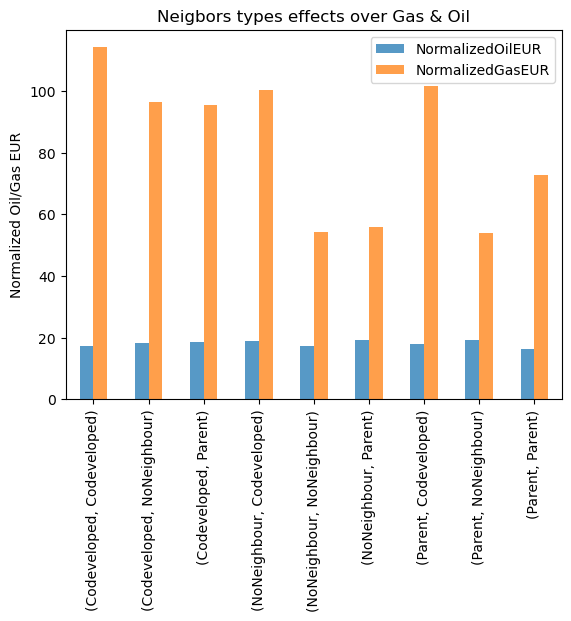

*codeveloped neighbors* might means higher Gas ratio and less oil

**From this observation we may choose whether we make ('no neigh'/ 'parent') as one option or just keep them both**.

**The Correlation between data Columns**

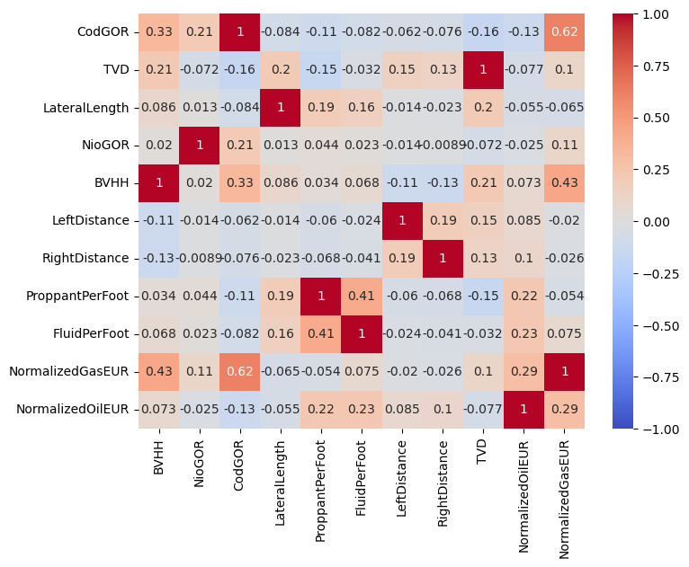

**Checking about Outliers in the data.**

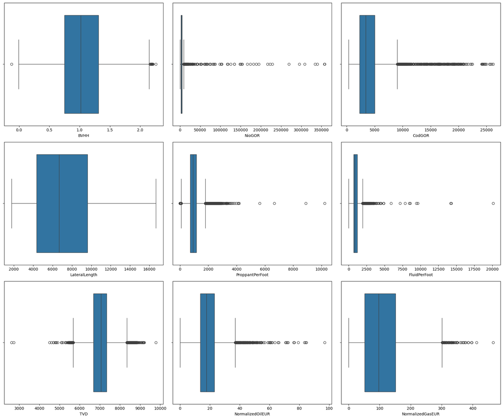

> It seems that The data is full of outliers - which will push us towards using a **RobustScaler** in the preprocessing pipeline before further actions.

**checking the correlation of soil type with the targets.**

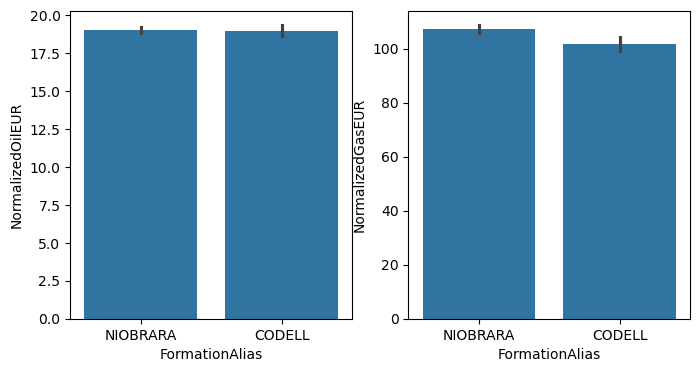

**It doesn't seem that that the type of FormationAlias that are represented in the data does actually make difference**

# 2. Manipulate and Clean the data for analysis.

## Explore for feature Engineering the data.

**checking again about na values before proceeding.**

```
BVHH                  1641
FormationAlias           0
NioGOR                 497
CodGOR                1668
LateralLength            0
ProppantPerFoot        232
FluidPerFoot           264
LeftDistance          2448
LeftNeighbourType        0
RightDistance         2428
RightNeighbourType       0
TVD                    313
NormalizedOilEUR         0
NormalizedGasEUR         0
dtype: int64
```

**it would be practically better to just know the distance of the neighbors more than in which direction, so we will add "neighDistance" by min of any wells neighbors**

|  | LeftDistance | RightDistance | neighDistance |
| --- | --- | --- | --- |
| 0 | NaN | NaN | NaN |
| 1 | 1330.0 | 1330.0 | 1330.0 |
| 2 | 1330.0 | 1330.0 | 1330.0 |
| 3 | NaN | NaN | NaN |
| 4 | NaN | NaN | NaN |

**After removing left/right dist .. we can fill neighDistance with zero, inf, or even mean but it's not practical right now to fill it with zero, as may in future "wells" can be discovered, so na values will be filled with Imputer later.**

```
BVHH                  1641
FormationAlias           0
NioGOR                 497
CodGOR                1668
LateralLength            0
ProppantPerFoot        232
FluidPerFoot           264
LeftNeighbourType        0
RightNeighbourType       0
TVD                    313
NormalizedOilEUR         0
NormalizedGasEUR         0
neighDistance         1465
dtype: int64
```

**since fluid and Proppant has higher correlation with the target columns, we can't just take the risk of letting the data be biased by filling them with random data, so we will drop their na rows.**

```
(8942, 13)
```

```
BVHH                  1630
FormationAlias           0
NioGOR                 474
CodGOR                1599
LateralLength            0
ProppantPerFoot          0
FluidPerFoot             0
LeftNeighbourType        0
RightNeighbourType       0
TVD                    295
NormalizedOilEUR         0
NormalizedGasEUR         0
neighDistance         1353
dtype: int64
```

**Statisically description of the data before scalling or filling the na(s).**

|  | BVHH | NioGOR | CodGOR | LateralLength | ProppantPerFoot | FluidPerFoot | TVD | NormalizedOilEUR | NormalizedGasEUR | neighDistance |
| --- | --- | --- | --- | --- | --- | --- | --- | --- | --- | --- |
| count | 7312.000000 | 8468.000000 | 7343.000000 | 8942.000000 | 8942.000000 | 8942.000000 | 8647.00000 | 8942.000000 | 8942.000000 | 7589.000000 |
| mean | 1.034276 | 4707.275296 | 4238.793565 | 7033.098331 | 1014.194397 | 1035.336411 | 7017.32254 | 18.998403 | 106.562998 | 673.829622 |
| std | 0.368010 | 12526.461276 | 3325.587987 | 2670.688644 | 528.301439 | 629.271011 | 614.78040 | 8.004233 | 66.317968 | 664.835889 |
| min | -0.125405 | 85.752059 | 336.475960 | 1749.000000 | 0.000000 | 0.001171 | 2610.00000 | 0.446867 | 0.000000 | 14.000000 |
| 25% | 0.755179 | 2199.869834 | 2329.889472 | 4377.250000 | 727.143814 | 703.318099 | 6687.00000 | 13.646120 | 52.239863 | 313.000000 |
| 50% | 1.025229 | 3468.353342 | 3419.641062 | 6764.000000 | 923.785016 | 862.066743 | 7065.00000 | 17.720051 | 98.059126 | 496.000000 |
| 75% | 1.310907 | 4903.486384 | 5009.286164 | 9612.000000 | 1153.524415 | 1207.024954 | 7349.50000 | 22.984912 | 151.723588 | 769.000000 |
| max | 2.260032 | 357894.183700 | 26193.592720 | 16676.000000 | 10217.314930 | 20117.640690 | 9793.00000 | 84.125736 | 465.849396 | 5276.000000 |

## Create the imputer and fit it on the training data.

a. choosing the columns that we are going to work with

```
Target Columns:  ['NormalizedOilEUR', 'NormalizedGasEUR']
**Used columns for predictions**
categorical columns:  ['LeftNeighbourType', 'RightNeighbourType', 'FormationAlias']
numerical columns :   ['BVHH', 'NioGOR', 'CodGOR', 'LateralLength', 'ProppantPerFoot', 'FluidPerFoot', 'TVD', 'neighDistance']
```

b. create our pipeline

```
ColumnTransformer(transformers=[('numeric_columns',
                                 Pipeline(steps=[('imputer',
                                                  KNNImputer(n_neighbors=20)),
                                                 ('scaler', RobustScaler())]),
                                 ['BVHH', 'NioGOR', 'CodGOR', 'LateralLength',
                                  'ProppantPerFoot', 'FluidPerFoot', 'TVD',
                                  'neighDistance']),
                                ('str_columns',
                                 Pipeline(steps=[('imputer',
                                                  SimpleImputer(strategy='most_frequent')),
                                                 ('encoding',
                                                  OneHotEncoder(handle_unknown='ignore'))]),
                                 ['LeftNeighbourType', 'RightNeighbourType',
                                  'FormationAlias'])])
```

## Splitting the data into "features and target" & "training and test data".

```
length of training data:  7153
length of testing data:  1789
```

**fit and transform the training data.**

**[first row] original training data**

```
BVHH                     1.105028
NioGOR                1687.414535
CodGOR                        NaN
LateralLength              8084.0
ProppantPerFoot       1256.308758
FluidPerFoot          1234.370856
TVD                        7501.0
neighDistance                 NaN
LeftNeighbourType     NoNeighbour
RightNeighbourType    NoNeighbour
FormationAlias           NIOBRARA
Name: 0, dtype: object
```

**[first row] data after preprocessing**

[output not shown]

**The Shape of the data after the pipeline (change of number of columns).**

```
original training data shape:  (7153, 11)
data after the pipeline shape:  (7153, 16)
```

**Before leaving the pre-processing of data step, This will be our used features.**

```
['BVHH' 'NioGOR' 'CodGOR' 'LateralLength' 'ProppantPerFoot' 'FluidPerFoot'
 'TVD' 'neighDistance' 'LeftNeighbourType' 'RightNeighbourType'
 'FormationAlias']
```

# 3. create a predictive model to get to know the most important features for our model to confirm our analysis.

## Training the model

```
Best parameters: {'max_depth': 30, 'n_estimators': 400}
```

```
GridSearchCV(cv=3, estimator=RandomForestRegressor(),
             param_grid={'max_depth': [30, 50, 100],
                         'n_estimators': [200, 400, 600]},
             scoring='neg_mean_squared_error')
```

### Actually the most important thing to get out of a tree model is "getting insights", So ... mainly in stage of analyzing the data -> our opportunity now is to get more insights.

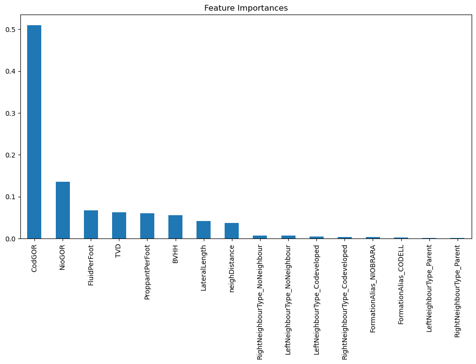

## test how our model perform on the test data.

```
the mae score of the model is:  12.752109116838128
The mae for Oil:  3.7963664360472382
The mae for Gas:  21.707851797629004
```

```
NormalizedOilEUR range of test data:  0.45  ->  76.2
NormalizedGasEUR range of test data:  0.0  ->  364.26
```

```
diff of Gas prediction to reality : 5.96%
diff of Oil prediction to reality : 5.01%
```